# Unit 6 - ARIMA Models and Seasonality

# For Live Session

1. Looking at your time series from the first day of class, you addressed its stationarity before. Does either a signal plus noise, ARIMA, or ARUMA (seasonal) model seem appropriate? (Just comment on your PowerPoint slide. We will test the fits of these models later.)
2. Copy and paste the factor table for a seasonal model with s = 7.
3. Consider the following models:

Model 1

$$\begin{equation}
(1 - B^4)X_{t} = (1 - .6B + .8B^2)a_{t}
\end{equation}$$

Model 2

$$\begin{equation}
(1 + .3B)X_{t} = (1 - .6B + .8B^2)a_{t}
\end{equation}$$

Model 3

$$\begin{equation}
(1 - .1B - .99B^2 + .013B^3 + .2078B^4 + .0888B^5 + .00864B^6)(1 - B)^2(1 - B^{12})X_{t} = (1 - .6B + .8B^2)a_{t}
\end{equation}$$

Comment and provide evidence (for each of the models) if they look to be:

ARUMA with d ≠0 and s≠0 ARUMA with d = 0 and s≠0 (Identify p and q as well.) ARIMA (Identify d as well as p and q.) ARMA (Identify p and q.)

4. Pick a stock and download the last year’s worth of daily stock price data.
- Plot the data.
- Take the first difference, and then estimate the structure of differenced data.
- From this information, suggest a model for the data.
5. Provide a slide or slides for your Key Takeaways for Unit 6!
6. Provide a slide or slides for any questions or comments you have from this section. This could also include topics you would like to have specifically addressed in live session! There is no minimum or maximum here.

```r
library(tidyverse)
library(tswge)
```

## Bikeshare Demand

```r
df_train <- read.csv(file="../../Unit 2/pre_live/data/train.csv", header = TRUE)

# df_train$datetime = as.POSIXct(df_train$datetime)

df_train$datetime = as.POSIXct(strptime(df_train$datetime, "%Y-%m-%d %H:%M:%S"))


df_train <- df_train %>%
  mutate(year = as.factor(format(datetime, format = "%Y")),
         month = as.numeric(format(datetime, format = "%m")),
         day = as.factor(format(datetime, format = "%d")),
         hour = as.factor(format(datetime, format = "%H")))
```

```r
df_dec_2012 <- df_train %>%
    filter(datetime >= "2012-12-01")
```

```r
aic5.wge(df_dec_2012$count)
```

```
---------WORKING... PLEASE WAIT...


Five Smallest Values of  aic
```

|  | p | q | aic |
| --- | --- | --- | --- |
| 14 | 4 | 1 | 9.163965 |
| 17 | 5 | 1 | 9.165910 |
| 18 | 5 | 2 | 9.171964 |
| 16 | 5 | 0 | 9.211459 |
| 15 | 4 | 2 | 9.213106 |

# Asynchronous Material

## 6.2 Signal Plus Noise Models vs. Stationary Models

### 6.2.4 Generate data from a signal-plus-noise model

[figure not shown]

[output not shown]

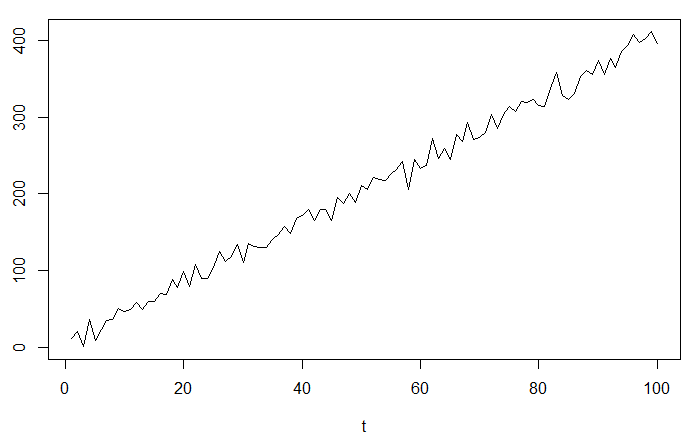

```r
# Randomly generating signal plus noise models

gen.sigplusnoise.wge(100, b0 = 2, b1 = 4, vara = 100)
```

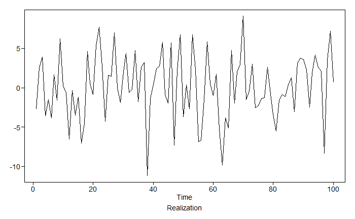

[output not shown]

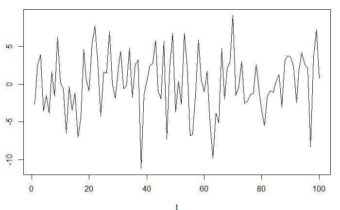

```r
gen.sigplusnoise.wge(100, b0 = 0, b1 = 0, vara = 10)
```

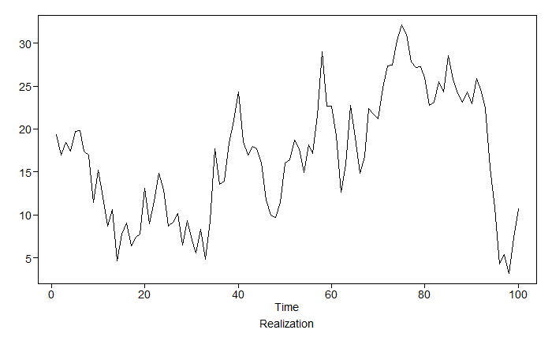

[output not shown]

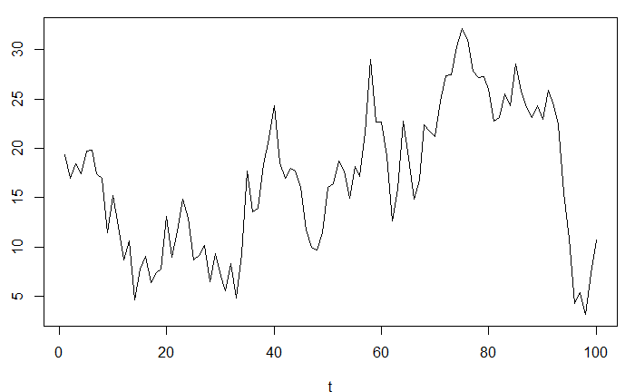

```r
gen.sigplusnoise.wge(100, b0 = 0, b1 = 0, phi = .975, vara = 10)
```

[figure not shown]

[output not shown]

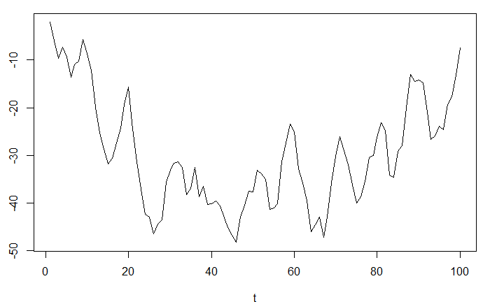

```r
# Periodic Signal

gen.sigplusnoise.wge(100, coef = c(5, 0), freq = c(.1, 0), psi = c(0,.25), phi = .975, vara = 10)
```

```r
# AR(4) from the slides

parms = mult.wge(c(.975), c(.2, -.45), c(-.53))
parms$model.coef
```

```
[1]  0.6450000 -0.0222500  0.0969000  0.2325375
```

[output not shown]

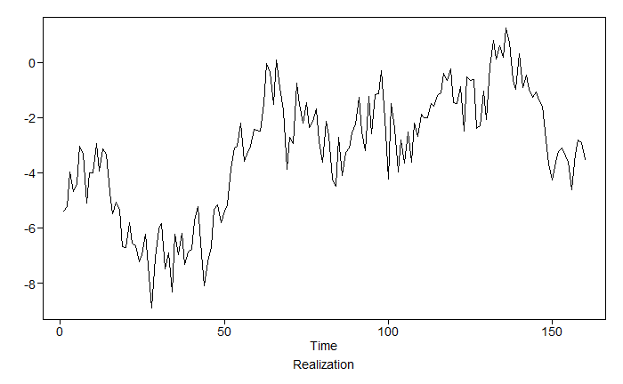

```r
gen.arma.wge(160, phi = parms$model.coef, vara = 1)
```

## 6.3 ARIMA Models, Part I

#### ARIMA Properties and Characteristics

ARIMA(p,d,q) Models

autoregressive integrated moving average process of orders p, d and q.

$$\begin{equation}
\phi(B)(1 - B)^dX_t = \theta(B)a_{t}
\end{equation}$$

Generate realizations from an ARIMA model. **gen.arima.wge**

### 6.3.3 P_k for an ARIMA process

$$\begin{equation}
\sigma^2_x = \gamma_0 = \frac{\sigma^2_a}{ 1 - \phi^2_1 }
\end{equation}$$

```r
variance = 2
# phi_1 = .4
phi_1 = .99

sigma_squared_x  = (variance) / (1 - phi_1^2)
sigma_squared_x
```

```
[1] 100.5025
```

### 6.3.4 ARIMA(0,1,0)

- Stricly wandering since there is one factor with a root of 1
- Identically equal to p_k = 1
- Slowly damping, even though the true values don’t damp

$$\begin{equation}
(1 - B)X_t = \alpha_t
\end{equation}$$

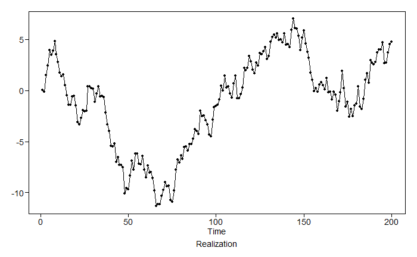

```r
x = gen.arima.wge(200, phi = 0, var = 1, d = 1, sn = 31)
```

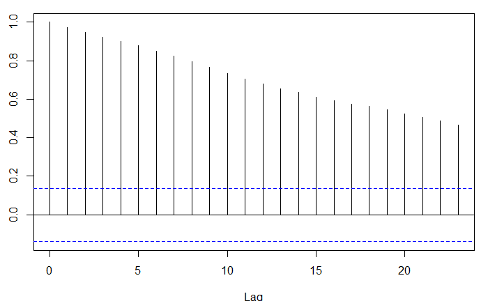

```r
acf(x)
```

## 6.4 ARIMA Models, Part II

### 6.4.1

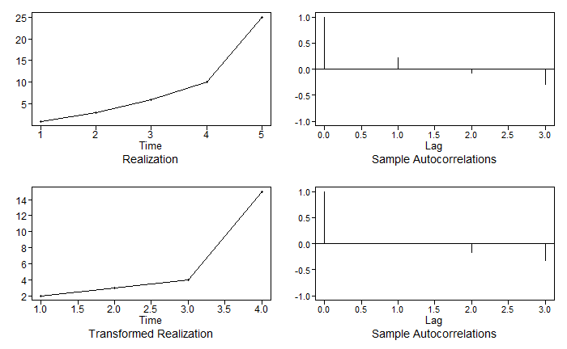

```r
# the following command differences the data in x

# y = artrans.wge(x, phi.tr = 1)

# This simply means that y(i) = x(i) - x(i - 1)

# y has length n-1 because x(1) has no x(0) before it.

# Example

x = c(1, 3, 6, 10, 25)

y = artrans.wge(x, phi.tr = 1)
```

```r
y # shows the 4 differences
```

```
[1]  2  3  4 15
```

### ARIMA(0,1,0)

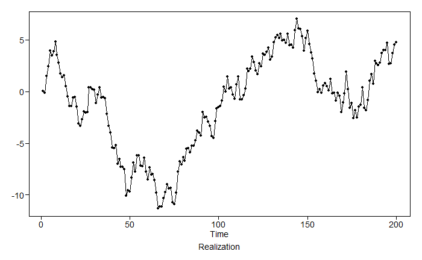

```r
# R Code

x = gen.arima.wge(200, phi = 0, var = 1, d = 1, sn = 31)
```

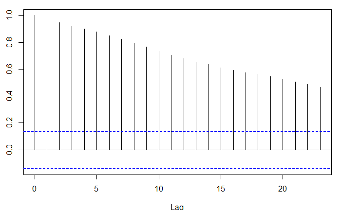

```r
acf(x)
```

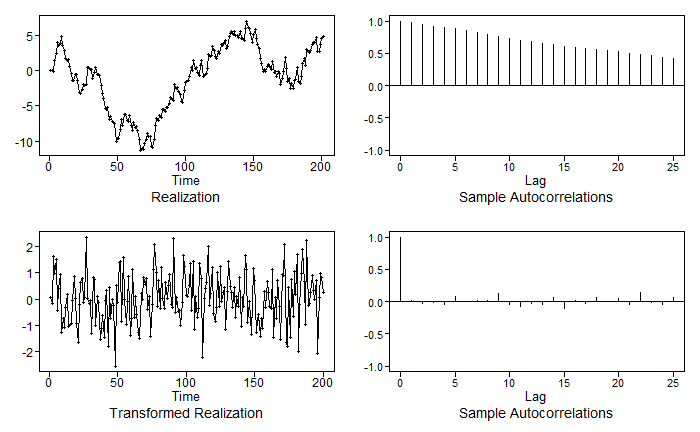

```r
Xtilde = artrans.wge(x, 1)
```

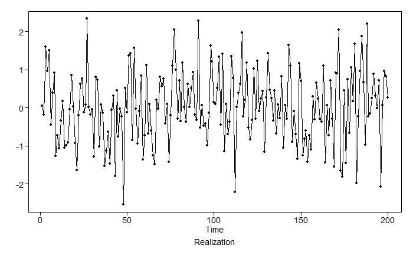

```r
plotts.wge(Xtilde)
```

```r
aic5.wge(Xtilde)
```

```
---------WORKING... PLEASE WAIT...


Five Smallest Values of  aic
```

|  | p | q | aic |
| --- | --- | --- | --- |
| 1 | 0 | 0 | -0.08725030 |
| 2 | 0 | 1 | -0.07740763 |
| 4 | 1 | 0 | -0.07740123 |
| 5 | 1 | 1 | -0.07016072 |
| 3 | 0 | 2 | -0.06785942 |

### ARIMA(2,1,0)

```r
# (1 - 1.5B + .8B^2)(1 - B)X_t = a_t

# R Code

a = gen.arima.wge(200, phi = c(1.5, -.8), var = 1, d = 1, sn = 31)
acf(a)

model = mult.wge(fac1 = c(1.5, -.8), fac2 = 1)
factor.wge(model$model.coef)

FirstDif = artrans.wge(a, 1) # Take out the (1-B)
parzen.wge(FirstDif)
aic5.wge(FirstDif) # Check the structure of the noise
```

[output not shown]

### ARIMA(2,2,1)

```r
# (1 - 1.5B + .8B^2)**(1 - B)^2**X_t = (1 + .8B)a_t

# R Code

a = gen.arima.wge(200, phi = c(1.5, -.8), theta = -.8, var = 1, d = 2, sn = 21)
acf(a)


p = parzen.wge(a, trunc = 40)
ar = mult.wge(fac1 = c(1.5, -.8), fac2 = 1, fac3 = 1)
factor.wge(ar$model.coef)


FirstDif = artrans.wge(a, 1) # Take out the (1-B)

SecondDif = artrans.wge(FirstDif, 1) # Take out the other (1-B)

parzen.wge(SecondDif)

aic5.wge(SecondDif) # Check the structure of the noise
```

[output not shown]

### ARIMA(2,2,1)

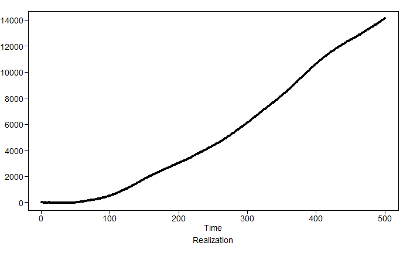

```r
# (1 - .6B + .8B^2)(1 - B)^2X_t = (1 + .3B)a_t

# R Code

a = gen.arima.wge(500, phi = c(.6, -.8), theta = -.3, var = 1, d = 2, sn = 35)
```

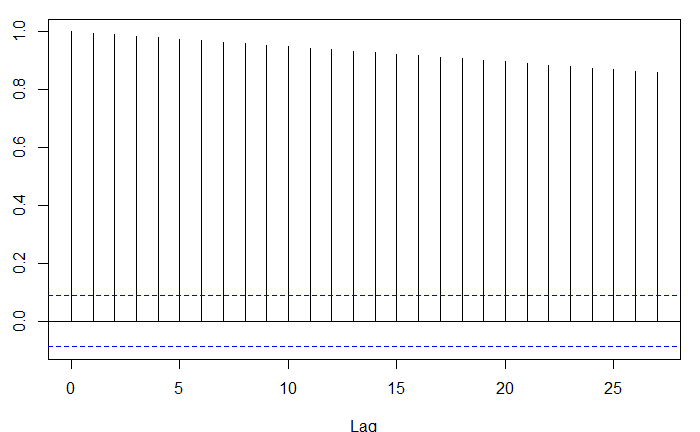

```r
acf(a)
```

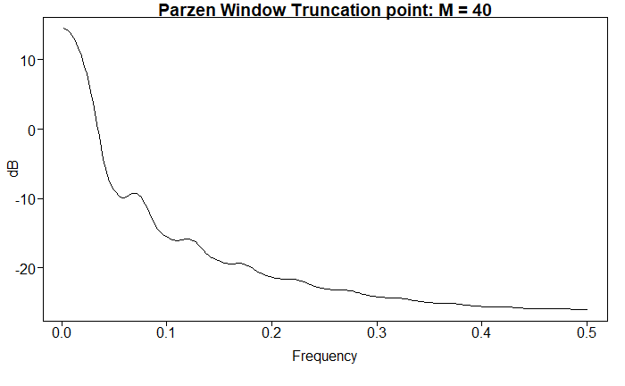

```r
p = parzen.wge(a, trunc = 40)
```

```r
ar = mult.wge(fac1 = c(.6, -.8), fac2 = 1, fac3 = 1)
factor.wge(ar$model.coef)
```

```
Coefficients of Original polynomial:
2.6000 -3.0000 2.2000 -0.8000

Factor                 Roots                Abs Recip    System Freq
1-1.0000B              1.0000               1.0000       0.0000
1-1.0000B              1.0000               1.0000       0.0000
1-0.6000B+0.8000B^2    0.3750+-1.0533i      0.8944       0.1956
```

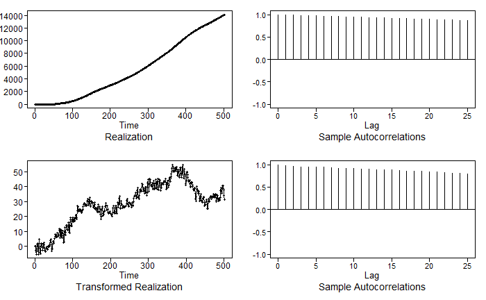

```r
FirstDif = artrans.wge(a, 1) # Take out the (1-B)
```

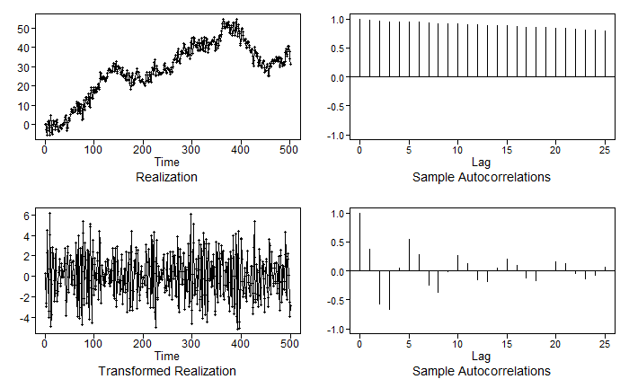

```r
SecondDif = artrans.wge(FirstDif, 1) # Take out the other (1-B)
```

[output not shown]

[output cut: 24 more lines]

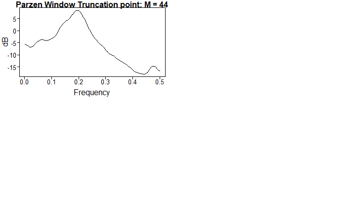

```r
parzen.wge(SecondDif)
```

```r
aic5.wge(SecondDif) # Check the structure of the noise
```

```
---------WORKING... PLEASE WAIT...


Five Smallest Values of  aic
```

|  | p | q | aic |
| --- | --- | --- | --- |
| 15 | 4 | 2 | 0.06130288 |
| 12 | 3 | 2 | 0.06411898 |
| 18 | 5 | 2 | 0.06510226 |
| 13 | 4 | 0 | 0.06654917 |
| 17 | 5 | 1 | 0.06674216 |